# Part II - (Prosper Loan)

## by (Fridah Arasa)

## (Visualization 1: Homeownership status of the borrowers at the time of borrowing.)

##### It's clear that majority of the borrowers were homeowners at the time. The percaentage number of homeowners was 50.4% and that of non-homeowners was 49.6%.

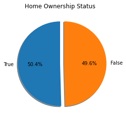

## (Visualization 2: Relationship between the Original loan amount and the term of the loan.)

##### The relationship between the original loan amount and the loan term is positive. This means that as the original loan amount increases the loan term also does the same.

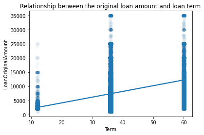

## (Visualization 3:Relationship between borrower rate and original loan amount )

##### There is a negative correlationship between the borrower rate and the orignal loan amount. This means that as the borrower rate increases, the original loan amount decreases.

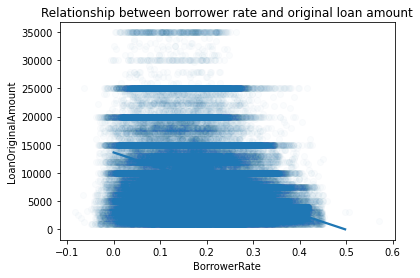

## (Visualization 4: Relationship between different variables.)

##### There is a positive correlationship between the investors, investment from friends, term, loan original amount and monthly loan payment. However there is a negative correlationship between monthly loan payment, loan original amount, investment from friends amount and borrower rate.There is a strong correlationship between loan original amount and monthly loan payment of 0.93. This indicates that the loan original amount influences the monthly loan that will be repaid.

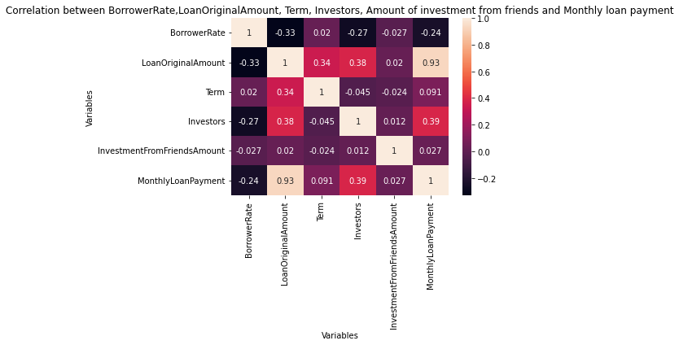